# R Notebook

Loading the dataset after downloading from Kaggle. Data Source: https://www.kaggle.com/c/prudential-life-insurance-assessment#description

```r
library(readr)
train <- read.csv("C:/Users/Sagar Ghiya/Desktop/train.csv")
```

Checking the structure of data

```r
str(train)
```

```
## 'data.frame':    59381 obs. of  128 variables:
##  $ Id                 : int  2 5 6 7 8 10 11 14 15 16 ...
##  $ Product_Info_1     : int  1 1 1 1 1 1 1 1 1 1 ...
##  $ Product_Info_2     : Factor w/ 19 levels "A1","A2","A3",..: 17 1 19 18 16 16 8 16 17 19 ...
##  $ Product_Info_3     : int  10 26 26 10 26 26 10 26 26 21 ...
##  $ Product_Info_4     : num  0.0769 0.0769 0.0769 0.4872 0.2308 ...
##  $ Product_Info_5     : int  2 2 2 2 2 3 2 2 2 2 ...
##  $ Product_Info_6     : int  1 3 3 3 3 1 3 3 3 3 ...
##  $ Product_Info_7     : int  1 1 1 1 1 1 1 1 1 1 ...
##  $ Ins_Age            : num  0.6418 0.0597 0.0299 0.1642 0.4179 ...
##  $ Ht                 : num  0.582 0.6 0.745 0.673 0.655 ...
##  $ Wt                 : num  0.149 0.132 0.289 0.205 0.234 ...
##  $ BMI                : num  0.323 0.272 0.429 0.352 0.424 ...
##  $ Employment_Info_1  : num  0.028 0 0.03 0.042 0.027 0.325 0.11 0.12 0.165 0.025 ...
##  $ Employment_Info_2  : int  12 1 9 9 9 15 1 12 9 1 ...
```

[output cut: 86 more lines]

Calculating the total number of missing values in the dataset

```r
sum(is.na(train))
```

```
## [1] 393103
```

Displaying each column with the number of missing values it has

```r
sapply(train, function(x) sum(is.na(x)))
```

```
##                  Id      Product_Info_1      Product_Info_2
##                   0                   0                   0
##      Product_Info_3      Product_Info_4      Product_Info_5
##                   0                   0                   0
##      Product_Info_6      Product_Info_7             Ins_Age
##                   0                   0                   0
##                  Ht                  Wt                 BMI
##                   0                   0                   0
##   Employment_Info_1   Employment_Info_2   Employment_Info_3
##                  19                   0                   0
##   Employment_Info_4   Employment_Info_5   Employment_Info_6
##                6779                   0               10854
##       InsuredInfo_1       InsuredInfo_2       InsuredInfo_3
##                   0                   0                   0
##       InsuredInfo_4       InsuredInfo_5       InsuredInfo_6
##                   0                   0                   0
##       InsuredInfo_7 Insurance_History_1 Insurance_History_2
##                   0                   0                   0
## Insurance_History_3 Insurance_History_4 Insurance_History_5
##                   0                   0               25396
## Insurance_History_7 Insurance_History_8 Insurance_History_9
##                   0                   0                   0
##       Family_Hist_1       Family_Hist_2       Family_Hist_3
##                   0               28656               34241
##       Family_Hist_4       Family_Hist_5   Medical_History_1
##               19184               41811                8889
##   Medical_History_2   Medical_History_3   Medical_History_4
##                   0                   0                   0
##   Medical_History_5   Medical_History_6   Medical_History_7
##                   0                   0                   0
##   Medical_History_8   Medical_History_9  Medical_History_10
##                   0                   0               58824
##  Medical_History_11  Medical_History_12  Medical_History_13
##                   0                   0                   0
##  Medical_History_14  Medical_History_15  Medical_History_16
##                   0               44596                   0
##  Medical_History_17  Medical_History_18  Medical_History_19
##                   0                   0                   0
##  Medical_History_20  Medical_History_21  Medical_History_22
##                   0                   0                   0
```

[output cut: 31 more lines]

```
##                   0                   0                   0
##  Medical_Keyword_30  Medical_Keyword_31  Medical_Keyword_32
##                   0                   0                   0
##  Medical_Keyword_33  Medical_Keyword_34  Medical_Keyword_35
##                   0                   0                   0
##  Medical_Keyword_36  Medical_Keyword_37  Medical_Keyword_38
##                   0                   0                   0
##  Medical_Keyword_39  Medical_Keyword_40  Medical_Keyword_41
##                   0                   0                   0
##  Medical_Keyword_42  Medical_Keyword_43  Medical_Keyword_44
##                   0                   0                   0
##  Medical_Keyword_45  Medical_Keyword_46  Medical_Keyword_47
##                   0                   0                   0
##  Medical_Keyword_48            Response
##                   0                   0
```

Removing columns that have large number of missing values as this would hamper our analysis. In all, 13 columns have missing values. 1 column only has 19 missing values, whereas other 12 have atleast 6779 missing values. So removing these 12 columns from the data frame.

```r
train_new1 <- train[,-c(16,18,30,35,36,37,38,39,48,53,62,70)]
```

Now 1 column remains that has 19 missing values. Checking the structure of that column so that a proper imputation strategy can be decided.

```r
str(train_new1$Employment_Info_1)
```

```
##  num [1:59381] 0.028 0 0.03 0.042 0.027 0.325 0.11 0.12 0.165 0.025 ...
```

Since the variable is continuous missing values can be imputed with the mean of the column. Using Machine Learning technique for data imputation is not a good idea as the dataset has more than 100 features.

```r
train_new1$Employment_Info_1[is.na(train_new1$Employment_Info_1)] = mean(train_new1$Employment_Info_1, na.rm=TRUE)
```

Checking one final time that all the missing values have been removed.

```r
sum(is.na(train_new1))
```

```
## [1] 0
```

First column is the “ID” column and will add no value to analysis. So removing it.

```r
train_new2 <- train_new1[,-1]
```

Again checking the structure of data to figure out columns that will have to be dummy coded.

```r
str(train_new2)
```

```
## 'data.frame':    59381 obs. of  115 variables:
##  $ Product_Info_1     : int  1 1 1 1 1 1 1 1 1 1 ...
##  $ Product_Info_2     : Factor w/ 19 levels "A1","A2","A3",..: 17 1 19 18 16 16 8 16 17 19 ...
##  $ Product_Info_3     : int  10 26 26 10 26 26 10 26 26 21 ...
##  $ Product_Info_4     : num  0.0769 0.0769 0.0769 0.4872 0.2308 ...
##  $ Product_Info_5     : int  2 2 2 2 2 3 2 2 2 2 ...
##  $ Product_Info_6     : int  1 3 3 3 3 1 3 3 3 3 ...
##  $ Product_Info_7     : int  1 1 1 1 1 1 1 1 1 1 ...
##  $ Ins_Age            : num  0.6418 0.0597 0.0299 0.1642 0.4179 ...
##  $ Ht                 : num  0.582 0.6 0.745 0.673 0.655 ...
##  $ Wt                 : num  0.149 0.132 0.289 0.205 0.234 ...
##  $ BMI                : num  0.323 0.272 0.429 0.352 0.424 ...
##  $ Employment_Info_1  : num  0.028 0 0.03 0.042 0.027 0.325 0.11 0.12 0.165 0.025 ...
##  $ Employment_Info_2  : int  12 1 9 9 9 15 1 12 9 1 ...
##  $ Employment_Info_3  : int  1 3 1 1 1 1 3 1 1 3 ...
```

[output cut: 86 more lines]

Converting the columns that need to be dummy coded into type “factor” because dummy.data.frame function only dummy codes columns that are “factor” type.

```r
train_new2[,c(1,2,3,5,6,7)] <- lapply(train_new2[,c(1,2,3,5,6,7)],factor)
train_new2[,13:66] <- lapply(train_new2[,13:66],factor)
```

```r
str(train_new2)
```

```
## 'data.frame':    59381 obs. of  115 variables:
##  $ Product_Info_1     : Factor w/ 2 levels "1","2": 1 1 1 1 1 1 1 1 1 1 ...
##  $ Product_Info_2     : Factor w/ 19 levels "A1","A2","A3",..: 17 1 19 18 16 16 8 16 17 19 ...
##  $ Product_Info_3     : Factor w/ 34 levels "1","2","3","4",..: 9 23 23 9 23 23 9 23 23 19 ...
##  $ Product_Info_4     : num  0.0769 0.0769 0.0769 0.4872 0.2308 ...
##  $ Product_Info_5     : Factor w/ 2 levels "2","3": 1 1 1 1 1 2 1 1 1 1 ...
##  $ Product_Info_6     : Factor w/ 2 levels "1","3": 1 2 2 2 2 1 2 2 2 2 ...
##  $ Product_Info_7     : Factor w/ 3 levels "1","2","3": 1 1 1 1 1 1 1 1 1 1 ...
##  $ Ins_Age            : num  0.6418 0.0597 0.0299 0.1642 0.4179 ...
##  $ Ht                 : num  0.582 0.6 0.745 0.673 0.655 ...
##  $ Wt                 : num  0.149 0.132 0.289 0.205 0.234 ...
##  $ BMI                : num  0.323 0.272 0.429 0.352 0.424 ...
##  $ Employment_Info_1  : num  0.028 0 0.03 0.042 0.027 0.325 0.11 0.12 0.165 0.025 ...
##  $ Employment_Info_2  : Factor w/ 36 levels "1","2","3","4",..: 11 1 8 8 8 14 1 11 8 1 ...
##  $ Employment_Info_3  : Factor w/ 2 levels "1","3": 1 2 1 1 1 1 2 1 1 2 ...
```

[output cut: 86 more lines]

Removing columns that have too many factor levels. If I don’t remove these, it goes to around 800+ columns only adding to computation.

```r
train_new3 <- train_new2[,-c(2,3,13,18,31)]
```

Dummy coding the dataframe. After dummy coding, there are around 206 variables or columns in the dataframe.

```r
library(dummies)
train_new4 <- dummy.data.frame(train_new3)
```

Next step is outlier detection. Checking continuous value columns for values that are 3 standard deviations away from the mean. However the data is already normalized to decrease the effect of outliers. There is nothing more that can be done at this stage for the outliers.

Also the fact that target variable is ordinal. So when risk category is maximum (8), the values ideally will be more. This is because many columns are based on fact that how many medical words does application contain and so on. With more such words, application becomes more risky and falls in category 8.

```r
sum(abs((train_new4[,3] - mean(train_new4[,3]))/sd(train_new4[,3]))>3)
```

```
## [1] 0
```

```r
sum(abs((train_new4[,11] - mean(train_new4[,11]))/sd(train_new4[,11]))>3)
```

```
## [1] 1
```

```r
sum(abs((train_new4[,12] - mean(train_new4[,12]))/sd(train_new4[,12]))>3)
```

```
## [1] 51
```

```r
sum(abs((train_new4[,13] - mean(train_new4[,13]))/sd(train_new4[,13]))>3)
```

```
## [1] 496
```

```r
sum(abs((train_new4[,14] - mean(train_new4[,14]))/sd(train_new4[,14]))>3)
```

```
## [1] 709
```

```r
sum(abs((train_new4[,15] - mean(train_new4[,15]))/sd(train_new4[,15]))>3)
```

```
## [1] 945
```

Next moving to machine learning models. Splitting the data into test and train in 70:30 ratio.

```r
require(caTools)
set.seed(123)
sample <- sample.split(train_new4, SplitRatio = .70)
trn <- subset(train_new4, sample == TRUE)
tst  <- subset(train_new4, sample == FALSE)
```

Checking if the response variable or target variable is more or less evenly split. This is to avoid situations when there are lots of cases with particular category in test dataset and they don’t occur much in train dataset and hence not accurately modeled.

But the split seems good.

```r
table(trn$Response)
```

```
##
##     1     2     3     4     5     6     7     8
##  4287  4602   691   998  3804  7783  5635 13619
```

```r
table(tst$Response)
```

```
##
##    1    2    3    4    5    6    7    8
## 1920 1950  322  430 1628 3450 2392 5870
```

Source for PCA: https://www.analyticsvidhya.com/blog/2016/03/practical-guide-principal-component-analysis-python/

For fitting machine learning models, PCA needs to be applied to reduce the 200+ columns.

Extracting the columns without target variable.

```r
prin_comp <- prcomp(trn[,1:204])
```

Checking the attributes of PCA.

```r
names(prin_comp)
```

```
## [1] "sdev"     "rotation" "center"   "scale"    "x"
```

Let’s check the center’s of the columns.

```r
prin_comp$center
```

```
##      Product_Info_11      Product_Info_12       Product_Info_4
##         9.739974e-01         2.600256e-02         3.297252e-01
##      Product_Info_52      Product_Info_53      Product_Info_61
##         9.928535e-01         7.146479e-03         1.649967e-01
##      Product_Info_63      Product_Info_71      Product_Info_72
##         8.350033e-01         9.774741e-01         0.000000e+00
##      Product_Info_73              Ins_Age                   Ht
##         2.252589e-02         4.055486e-01         7.071906e-01
##                   Wt                  BMI    Employment_Info_1
##         2.924968e-01         4.694037e-01         7.776541e-02
##   Employment_Info_31   Employment_Info_33   Employment_Info_52
##         8.494652e-01         1.505348e-01         8.561288e-01
##   Employment_Info_53       InsuredInfo_11       InsuredInfo_12
##         1.438712e-01         7.942732e-01         2.014534e-01
##       InsuredInfo_13       InsuredInfo_22       InsuredInfo_23
##         4.273401e-03         9.928294e-01         7.170622e-03
##       InsuredInfo_42       InsuredInfo_43       InsuredInfo_51
##         1.168787e-01         8.831213e-01         9.866004e-01
##       InsuredInfo_53       InsuredInfo_61       InsuredInfo_62
##         1.339965e-02         5.898501e-01         4.101499e-01
##       InsuredInfo_71       InsuredInfo_73 Insurance_History_11
##         9.809991e-01         1.900094e-02         2.722181e-01
## Insurance_History_12 Insurance_History_21 Insurance_History_22
##         7.277819e-01         9.729351e-01         0.000000e+00
## Insurance_History_23 Insurance_History_31 Insurance_History_32
##         2.706487e-02         4.248775e-01         2.414351e-05
## Insurance_History_33 Insurance_History_41 Insurance_History_42
##         5.750984e-01         4.699775e-01         1.041551e-01
## Insurance_History_43 Insurance_History_71 Insurance_History_72
##         4.258674e-01         5.269321e-01         4.717642e-02
## Insurance_History_73 Insurance_History_81 Insurance_History_82
##         4.258915e-01         2.613776e-01         4.258915e-01
## Insurance_History_83 Insurance_History_91 Insurance_History_92
##         3.127309e-01         8.184650e-03         5.658756e-01
## Insurance_History_93       Family_Hist_11       Family_Hist_12
##         4.259398e-01         9.150390e-03         2.935368e-01
##       Family_Hist_13   Medical_History_31   Medical_History_32
##         6.973128e-01         2.414351e-05         8.983558e-01
##   Medical_History_33   Medical_History_41   Medical_History_42
##         1.016200e-01         3.438760e-01         6.561240e-01
```

[output cut: 81 more lines]

```
##         8.918612e-02         1.364108e-02         1.166131e-02
##   Medical_Keyword_28   Medical_Keyword_29   Medical_Keyword_30
##         1.504141e-02         1.158888e-02         2.455395e-02
##   Medical_Keyword_31   Medical_Keyword_32   Medical_Keyword_33
##         1.103358e-02         2.069099e-02         2.267075e-02
##   Medical_Keyword_34   Medical_Keyword_35   Medical_Keyword_36
##         2.061856e-02         6.808470e-03         9.947126e-03
##   Medical_Keyword_37   Medical_Keyword_38   Medical_Keyword_39
##         6.649122e-02         6.567034e-03         1.344793e-02
##   Medical_Keyword_40   Medical_Keyword_41   Medical_Keyword_42
##         5.613366e-02         9.874695e-03         4.580024e-02
##   Medical_Keyword_43   Medical_Keyword_44   Medical_Keyword_45
##         1.122673e-02         7.412057e-03         1.376180e-02
##   Medical_Keyword_46   Medical_Keyword_47   Medical_Keyword_48
##         8.691663e-03         2.047370e-02         5.400903e-02
```

Rotation gives us the loadings of the PCA

```r
prin_comp$rotation
```

```
##                                PC1           PC2           PC3
## Product_Info_11      -6.997923e-04  6.096115e-03 -4.639264e-03
## Product_Info_12       6.997923e-04 -6.096115e-03  4.639264e-03
## Product_Info_4        4.494245e-03  5.087014e-03  7.573793e-02
## Product_Info_52       1.434949e-03  1.299026e-03 -1.831530e-03
## Product_Info_53      -1.434949e-03 -1.299026e-03  1.831530e-03
## Product_Info_61      -2.929762e-03  8.360394e-03 -4.099050e-03
## Product_Info_63       2.929762e-03 -8.360394e-03  4.099050e-03
## Product_Info_71       3.854239e-03  5.499028e-03  2.762266e-03
## Product_Info_72       0.000000e+00  0.000000e+00  0.000000e+00
## Product_Info_73      -3.854239e-03 -5.499028e-03 -2.762266e-03
## Ins_Age              -4.396332e-02 -9.490514e-03 -8.422023e-02
## Ht                   -4.998172e-03 -1.018384e-02  9.025012e-03
## Wt                   -6.415581e-03 -1.161065e-02 -9.090499e-03
## BMI                  -5.932708e-03 -9.291807e-03 -2.565669e-02
## Employment_Info_1    -8.136221e-03 -1.166721e-03  9.704451e-03
## Employment_Info_31    3.589012e-05  1.859470e-02  1.370783e-01
## Employment_Info_33   -3.589012e-05 -1.859470e-02 -1.370783e-01
## Employment_Info_52   -1.572940e-02  3.991377e-03  5.401763e-02
## Employment_Info_53    1.572940e-02 -3.991377e-03 -5.401763e-02
## InsuredInfo_11       -5.113415e-02 -1.055498e-01 -1.060345e-01
## InsuredInfo_12        4.819931e-02  1.040788e-01  1.042906e-01
## InsuredInfo_13        2.934834e-03  1.471021e-03  1.743891e-03
## InsuredInfo_22       -1.875172e-03  2.045222e-03 -1.502328e-03
## InsuredInfo_23        1.875172e-03 -2.045222e-03  1.502328e-03
## InsuredInfo_42       -2.323782e-04 -3.211974e-02  5.556379e-03
## InsuredInfo_43        2.323782e-04  3.211974e-02 -5.556379e-03
## InsuredInfo_51       -4.570373e-03  4.149013e-03  9.724226e-05
## InsuredInfo_53        4.570373e-03 -4.149013e-03 -9.724226e-05
## InsuredInfo_61       -3.244456e-02 -5.390998e-02  9.835408e-02
## InsuredInfo_62        3.244456e-02  5.390998e-02 -9.835408e-02
## InsuredInfo_71       -6.912050e-03 -5.583892e-04 -1.960833e-03
## InsuredInfo_73        6.912050e-03  5.583892e-04  1.960833e-03
## Insurance_History_11 -1.737699e-01 -3.716646e-02 -6.073907e-02
## Insurance_History_12  1.737699e-01  3.716646e-02  6.073907e-02
## Insurance_History_21  3.360637e-03  1.096433e-02  1.594720e-02
## Insurance_History_22  0.000000e+00  0.000000e+00 -1.469368e-39
## Insurance_History_23 -3.360637e-03 -1.096433e-02 -1.594720e-02
## Insurance_History_31  3.130195e-01 -5.380414e-02 -5.014286e-02
## Insurance_History_32  1.429726e-05 -1.276946e-05  1.979952e-05
```

[output cut: 13885 more lines]

```
## Medical_Keyword_34    8.673617e-18 -4.119968e-18 -1.637145e-17
## Medical_Keyword_35    1.246832e-17 -1.643244e-17  3.632077e-17
## Medical_Keyword_36    1.010476e-16 -4.854515e-17 -5.659535e-17
## Medical_Keyword_37   -1.063602e-16  2.596325e-17  1.104124e-16
## Medical_Keyword_38   -4.531965e-17 -3.316439e-16  6.873842e-17
## Medical_Keyword_39    1.552578e-16  3.380000e-17  8.771196e-17
## Medical_Keyword_40    9.020562e-17 -5.149960e-18  3.252607e-18
## Medical_Keyword_41    1.387779e-17 -1.214306e-17  4.770490e-18
## Medical_Keyword_42   -8.933826e-17 -2.325614e-17  1.064687e-16
## Medical_Keyword_43    1.862219e-16 -4.979558e-17 -5.474628e-17
## Medical_Keyword_44   -8.890458e-17  1.176359e-17  6.179952e-17
## Medical_Keyword_45   -7.494548e-18  1.369661e-16  8.324301e-17
## Medical_Keyword_46   -7.036472e-17  2.146043e-17 -1.257675e-17
## Medical_Keyword_47   -1.307548e-16  5.347827e-17 -5.992928e-17
## Medical_Keyword_48   -1.700029e-16  1.204549e-16  4.891920e-16
```

Ensuring the dimensions after PCA match with our dataframe.

```r
dim(prin_comp$x)
```

```
## [1] 41419   204
```

Creating biplot to check for feature importance.

[output not shown]

[output cut: 37 more lines]

[output not shown]

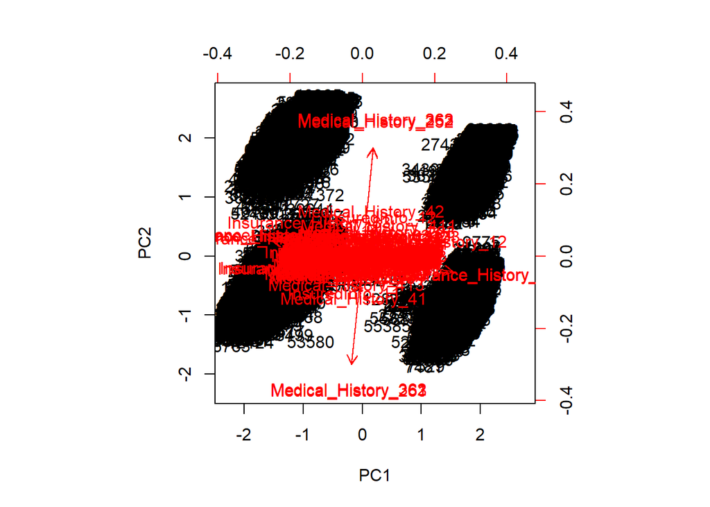

```r
biplot(prin_comp, scale = 0)
```

Taking standard deviation values in a variable

```r
std_dev <- prin_comp$sdev
```

Calculating variance.

```r
pr_var <- std_dev^2
```

Let’s see the the proportion of variance each component in PCA covers.

```r
prop_varex <- pr_var/sum(pr_var)
prop_varex
```

```
##   [1] 1.933997e-01 7.543438e-02 6.257017e-02 5.326379e-02 4.505276e-02
##   [6] 3.661203e-02 3.116694e-02 3.059071e-02 2.564215e-02 2.435513e-02
##  [11] 2.372451e-02 2.229416e-02 2.068007e-02 1.978211e-02 1.951306e-02
##  [16] 1.805680e-02 1.706615e-02 1.592908e-02 1.572662e-02 1.505426e-02
##  [21] 1.397120e-02 1.305580e-02 1.287993e-02 1.196984e-02 1.180792e-02
##  [26] 1.115203e-02 9.283586e-03 8.832610e-03 8.662032e-03 7.543421e-03
##  [31] 6.486017e-03 6.224257e-03 5.758938e-03 5.240480e-03 4.744615e-03
##  [36] 4.518142e-03 4.167925e-03 3.966550e-03 3.887673e-03 3.654729e-03
##  [41] 3.562191e-03 3.434088e-03 3.012093e-03 2.593960e-03 2.490049e-03
##  [46] 2.351393e-03 2.320540e-03 2.286974e-03 2.101211e-03 1.884859e-03
##  [51] 1.759971e-03 1.654269e-03 1.606076e-03 1.558703e-03 1.529764e-03
##  [56] 1.461457e-03 1.411818e-03 1.376980e-03 1.326595e-03 1.245170e-03
##  [61] 1.227570e-03 1.193540e-03 1.186199e-03 1.152726e-03 1.122230e-03
##  [66] 1.114824e-03 1.079368e-03 1.076832e-03 1.063325e-03 1.045826e-03
##  [71] 1.017792e-03 9.581210e-04 9.378947e-04 9.326266e-04 8.729614e-04
```

[output cut: 26 more lines]

Making some exploratory plots for analysis.

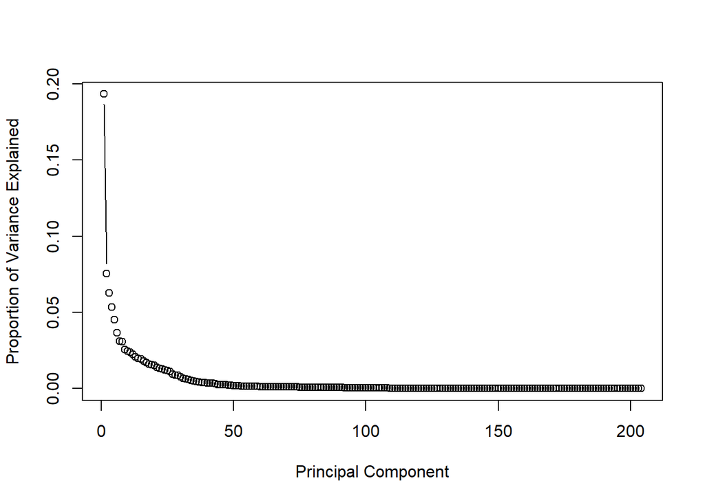

```r
plot(prop_varex, xlab = "Principal Component",
             ylab = "Proportion of Variance Explained",
             type = "b")
```

Similar things can be observed from cumulative plot.

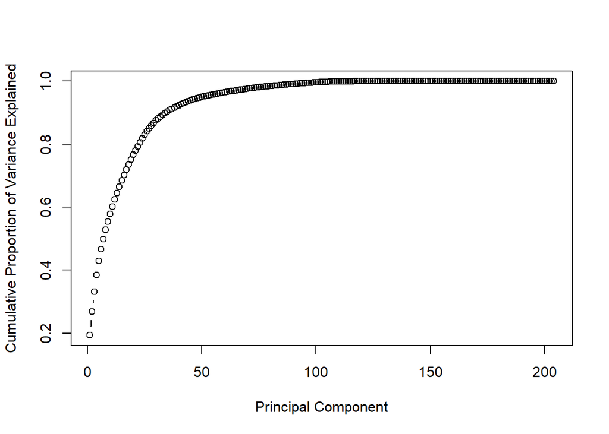

```r
plot(cumsum(prop_varex), xlab = "Principal Component",
              ylab = "Cumulative Proportion of Variance Explained",
              type = "b")
```

Making data frame from principal components.

```r
trn.data <- data.frame(prin_comp$x)
```

Taking the first 50 componets and adding the target variable column.

```r
trn.data <- trn.data[,1:50]
trn.data_final <- data.frame(trn.data, Response = trn$Response)
```

Making predictions on test data to get principal components for test data.

```r
tst.data <- predict(prin_comp, newdata = tst[,1:204])
tst.data <- tst.data[,1:50]
tst.data_final <- data.frame(tst.data, Response = tst$Response)
```

Ensuring the target variable is of type “factor”

```r
trn.data_final$Response <- factor(trn.data_final$Response)
tst.data_final$Response <- factor(tst.data_final$Response)
```

Now starting to build machine learning models. First, let’s check the accuracy of base model. This means that how much accuracy can be obtained without doing any machine learning.

Since category 8 occurs most frequently, we can consider or predict all cases as category 8. This gives accuracy as 32.82%. Thus aim for the project should be to build models that improve accuracy above 32%.

```r
table(train$Response)
```

```
##
##     1     2     3     4     5     6     7     8
##  6207  6552  1013  1428  5432 11233  8027 19489
```

Accuracy for base model = (19489/59381) * 100 = 32.82%

# NaiveBayes

First model I am fitting is Naive Bayes. This is the only model that I am fitting on original dataset(having 206 columns) as columns obtained from PCA are continuous and Naive Bayes won’t be a good model.

I decided to fit this model as majority of variables in original data frame are categorical and dummy coded.

```r
library(e1071)
trn$Response <- factor(trn$Response)
tst$Response <- factor(tst$Response)
model_nb <- naiveBayes(Response~. , data = trn)
```

Making predictions on train data.

```r
pred_trn <- predict(model_nb, trn[,1:204])
```

Forming confusion matrix for predictions

```r
b <- table(pred_trn,trn$Response)
b
```

```
##
## pred_trn    1    2    3    4    5    6    7    8
##        1  655  388   13   16  128  314  152  212
##        2  434  597   24   20  222  351  182  262
##        3 1185 1371  242  164  975 1517  639  909
##        4  801  901  333  695 1282 3108 2022 4320
##        5  283  411   15    5  257  353  140  169
##        6  101  112    2    5   58  207   53  100
##        7  500  521   35   37  426 1079 1303 1263
##        8  328  301   27   56  456  854 1144 6384
```

Evaluating accuracy

```r
(sum(diag(b))/sum(b)) *100
```

```
## [1] 24.96439
```

It is observed that accuracy is even less than base model accuracy. One possible reason that Naive Bayes doesn’t work well is that columns are dependent on each other and the target variable is also ordinal.

Since Naive Bayes assumes that columns or features should be independent of each other, it doesn’t work well.

Predicting on test dataset

```r
pred_nb_tst <- predict(model_nb, tst[,1:204])
```

Making confusion matrix

```r
a <- table(pred_nb_tst,tst$Response)
a
```

```
##
## pred_nb_tst    1    2    3    4    5    6    7    8
##           1  252  174   18   10   70  143   63  101
##           2  200  227   10    9  105  172   70  101
##           3  507  586   94   64  371  664  286  411
##           4  387  396  162  284  547 1413  916 1905
##           5  130  176    5    4  107  166   57   73
##           6   51   38    5    3   19  105   35   45
##           7  230  221   17   26  209  447  492  566
##           8  163  132   11   30  200  340  473 2668
```

Checking for accuracy

```r
(sum(diag(a))/sum(a)) *100
```

```
## [1] 23.54415
```

# Support Vector Machine with Gaussian Kernel

# Some generic notes for future models

# For all the models, I wanted to tune the parameters using caret package and k fold cross validation. However the simple model is taking too long to train. So making k folds and tuning would take couple of hours for a single model which is not feasible.

# However I have manually tried different tuning values and selected one’s that give best accuracy. Just that k fold wasn’t possible. I am also demonstrating a small code below that shows that I can tune parameters using kfold.

library(caret) trctrl <- trainControl(method = “repeatedcv”, number = 10, repeats = 3) svm_radial <- train(Response~. , data = trn.data_final, method = “svmRadial”, trControl = trctrl, preProcess = c(“center”, “scale”), tuneLength = 10)

Training with SVM

```r
library(kernlab)
model_svm_rbf <- ksvm(Response~. , data = trn.data_final, kernel = 'rbf')
```

Making predictions on train data

```r
svm_pred_trn <- predict(model_svm_rbf, trn.data_final)
```

Building confusion matrix

```r
sv_trn <- table(svm_pred_trn,trn.data_final$Response)
sv_trn
```

```
##
## svm_pred_trn     1     2     3     4     5     6     7     8
##            1  1794   267    63    44   178   193   116    61
##            2   415  1843    49    29   340   307   154    79
##            3     0     0    12     0     0     0     0     0
##            4     0     0     0     6     1     0     0     0
##            5    28    38     3     0   330    23    22     7
##            6   792   916   375   519   902  4271   965  1163
##            7   257   269    17    13   290   486  1567   142
##            8  1001  1269   172   387  1763  2503  2811 12167
```

Evaluating accuracy on train data

```r
(sum(diag(sv_trn))/sum(sv_trn)) *100
```

```
## [1] 53.09158
```

Predictions on test dataset

```r
svm_pred_tst <- predict(model_svm_rbf, tst.data_final[,1:50])
```

Making Confusion matrix

```r
sv_tst <- table(svm_pred_tst,tst.data_final$Response)
sv_tst
```

```
##
## svm_pred_tst    1    2    3    4    5    6    7    8
##            1  492  300   32   19  107  210   88   73
##            2  295  379   28    7  142  251  106   76
##            3    0    0    0    0    1    0    0    0
##            4    0    1    1    0    0    0    0    0
##            5   19   28    2    0   46   24   33    4
##            6  456  527  168  219  447 1575  475  584
##            7  133  140    3   11  134  263  468   70
##            8  525  575   88  174  751 1127 1222 5063
```

Evaluating accuracy

```r
(sum(diag(sv_tst))/sum(sv_tst)) *100
```

```
## [1] 44.66652
```

For SVM: Train accuracy = 53% and test accuracy = 45%. SVM gives decent results given the complexity of the dataset.

# Multinomial Regression

Multinomial regression is similar to logistic regression when there are more than 2 classes. It adopts a one-versus all approach in which it assumes one class as 1 and all the remaining classes as 0 and repeats this for all the classes.

It is linear classifier and makes 8 different hyperplanes in this case for classification.

I have tuned the max iterations parameter to a very large value so that it allows enough iterations for the gradient descent optimization to converge and reach global minima and give optimal weight values.

```r
library(nnet)
model_logistic <- multinom(Response~. , data = trn.data_final, maxit = 100000
                           )
```

Making predictions and thus confusion matrix on train data.

```r
pred_logistic <- predict(model_logistic,trn.data_final[,1:50])
mt <- table(pred_logistic, trn.data_final$Response)
mt
```

```
##
## pred_logistic     1     2     3     4     5     6     7     8
##             1  1111   620    56    31   234   486   228   121
##             2   570   903    39    18   339   456   178   129
##             3    14     9    18     2     3     9     1     0
##             4    15    22    20    39    19    23     7    20
##             5    51    61     8     0    86    43    37    24
##             6  1026  1154   396   542   938  3169  1015  1343
##             7   347   398     9    12   364   639  1198   158
##             8  1153  1435   145   354  1821  2958  2971 11824
```

Evaluating train accuracy

```r
(sum(diag(mt))/sum(mt)) *100
```

```
## [1] 44.29851
```

Predictions and confusion matrix on test dataset

```r
pred_logistic_tst <- predict(model_logistic, tst.data_final[,1:50])
mt1 <- table(pred_logistic_tst, tst.data_final$Response)
mt1
```

```
##
## pred_logistic_tst    1    2    3    4    5    6    7    8
##                 1  477  285   31   15   97  218   79   46
##                 2  262  348   20    6  137  224   81   70
##                 3   10    4    5    1    0    5    0    3
##                 4    6    8    9    8    4   12    0    7
##                 5   21   35    5    0   22   23   19   15
##                 6  434  497  175  226  421 1467  443  569
##                 7  159  171    4    4  172  297  504   69
##                 8  551  602   73  170  775 1204 1266 5091
```

Evaluating test accuracy

```r
(sum(diag(mt1))/sum(mt1)) *100
```

```
## [1] 44.10422
```

For multinomial regression: Train accuracy: 44% ; Test Accuracy = 44% Decent results but not as good as SVM.

# Neural Networks with 10 neurons in hidden layer

Small snippet of code showing I can tune parameters with k fold CV and holdout method. However not feasible due to computation. But I tried many different parameters within computation capacity and used the best one with max accuracy.

nnetGrid <- expand.grid(.size = c(10:20,10:20), .decay = c(0.01,0.001,0.0001)) ctrl <- trainControl(method = “repeatedcv”, number = 10, repeats = 3) model_neural <- train(Response~. , data = trn.data_final, method = “nnet”, tuneGrid = nnetGrid, trControl = ctrl, preProc = c(“center”, “scale”), maxit = 10000)

Training neural network. Here there are 10 neurons in one and only hidden layer. Decay rate is kept to be 0.001, this refers to the learning rate or the rate at which algorithm comes down the gradient to reach minima. Tuned max iterations to a large value so that there are enough iterations for convergence.

```r
library(nnet)
model_neural <- nnet(Response~. ,data = trn.data_final, size = c(10), decay = 0.001, maxit = 10000)
```

[output not shown]

Making predictions from the neural network. Predictions come as probabilities since the activation function is sigmoid. Figure out class with maximum accuracy using for loop.

```r
pred_nn <- predict(model_neural, trn.data_final[,1:50])
df_nn <- data.frame(pred_nn)
df_nn$new <- 0
for(i in 1:nrow(df_nn)) {
  df_nn[i,9] <- which.max(df_nn[i,1:8])
}
```

Making confusion matrix for train data

```r
nn <- table(df_nn[,9], trn.data_final$Response)
nn
```

```
##
##         1     2     3     4     5     6     7     8
##   1  1160   654    69    33   302   534   241   160
##   2   595   893    39     3   485   509   119    51
##   3     2    10    18     1    14     0     0     0
##   4     5    12    10    33     0    24    16    23
##   5   303   590    93     1  1226   334   100    43
##   6   981  1204   376   495  1021  3451  1292  1058
##   7   328   319    10    13   290   688  1416   300
##   8   913   920    76   419   466  2243  2451 11984
```

Evaluating train data accuracy

```r
(sum(diag(nn))/sum(nn)) *100
```

```
## [1] 48.72402
```

Making predictions on test data

```r
pred_nn_tst <- predict(model_neural, tst.data_final[,1:50])
df_nn_tst <- data.frame(pred_nn_tst)
df_nn_tst$new <- 0
for(i in 1:nrow(df_nn_tst)) {
  df_nn_tst[i,9] <- which.max(df_nn_tst[i,1:8])
}
```

Building confusion matrix on test data

```r
nn_tst <- table(df_nn_tst[,9], tst.data_final$Response)
nn_tst
```

```
##
##        1    2    3    4    5    6    7    8
##   1  480  313   30   15  129  280   89   66
##   2  266  338   22    2  219  247   35   34
##   3    4    1    9    0    8    0    0    0
##   4    4    3    3   15    0    9    3   13
##   5  151  257   56    1  480  130   55   20
##   6  438  500  161  190  439 1465  584  506
##   7  156  144    6   10  131  320  588  122
##   8  421  394   35  197  222  999 1038 5109
```

Evaluating accuracy on test data.

```r
(sum(diag(nn_tst))/sum(nn_tst)) *100
```

```
## [1] 47.23305
```

For Neural Network: Train Accuracy = 49% ; Test Accuracy = 47% Neural Network results outperform both SVM and Multinomial Regression

# Ensemble model using voting

Trying to improve accuracy using voting. In this I have created data frame with 3 columns having predictions for all the 3 models implemented(excluding NaiveBayes).

Then created a new column for majority voting. If any 2 columns are same or predict same classes, the majority vote column takes that value. In rare case, if all the three models are predicting 3 different class for a case, then the majority vote column takes value from neural net prediction as neural network is giving best results.

Making data frame from 3 different predictions

```r
vot_df <- data.frame(svm_pred_tst, pred_logistic_tst, df_nn_tst[,9])
```

Running for loop for each case. Majority vote in new column takes value which is there in atleast 2 columns. If all 3 columns have different classes, neural network class is predicted.

```r
vot_df$new <- 0
for(i in 1:nrow(vot_df)) {
  if(vot_df[i,1]==vot_df[i,2])
    vot_df[i,4] = vot_df[i,1]
  else if(vot_df[i,1]==vot_df[i,3])
    vot_df[i,4] = vot_df[i,1]
  else if(vot_df[i,2]==vot_df[i,3])
    vot_df[i,4] = vot_df[i,2]
  else vot_df[i,4] = vot_df[i,3]

}
```

Building confusion matrix on ensemble model

```r
ensemble <- table(vot_df$new, tst.data_final$Response)
ensemble
```

```
##
##        1    2    3    4    5    6    7    8
##   1  481  297   32   15   97  221   84   52
##   2  261  361   21    3  158  220   52   42
##   3    3    1    3    0    2    0    0    0
##   4    2    2    1    3    0    6    2    3
##   5   49   54   12    0   48   25   22    4
##   6  445  503  180  227  433 1533  484  571
##   7  154  158    3    6  154  290  497   69
##   8  525  574   70  176  736 1155 1251 5129
```

Evaluating ensemble model

```r
(sum(diag(ensemble))/sum(ensemble)) *100
```

```
## [1] 44.84467
```

Test accuracy for ensemble = 45% which is better than multinomial regression and SVM. However this approach doesn’t give more accuracy than neural networks.

Having said that, neural networks have way more capability to give more better results when we add more hidden layers and more neurons in each layer. Unfortunately, I couldn’t do that due to large computation that it will require.

Thus I conclude that Neural Networks is the way to go for the prudential dataset on Kaggle.

I observed that top performers in Kaggle for this dataset have been able to get accuracy close to 60%. I have been abe to reach 48% with neural network. Thus my goal in summer is to invest more time in this dataset to see what I can do or learn more that would help me reach that mark.